# Assignment3

## Initial Regression Analysis: Bathrooms and Rooms

```r
houses_fit <- lm(Bathroom~Rooms, data=houses1)
tidy(houses_fit)
```

```
##          term  estimate  std.error statistic      p.value
## 1 (Intercept) 0.1932662 0.01187227  16.27879 2.700918e-59
## 2       Rooms 0.4616509 0.00365747 126.22137 0.000000e+00
```

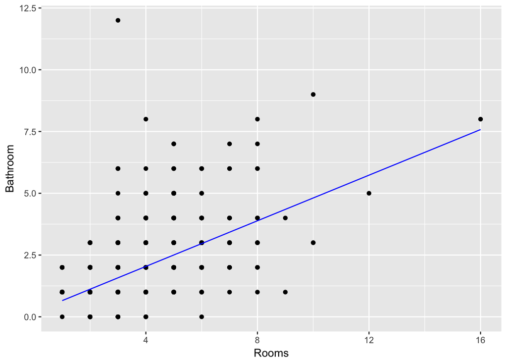

```r
bathroom_model <- augment(houses_fit, houses1)
ggplot(bathroom_model, aes(x=Rooms, y=Bathroom)) +
     geom_point() +
     geom_line(aes(y=.fitted), colour="blue")
```

## Initial Regression Analysis: Bedrooms and Rooms

```r
houses_fit2 <- lm(Bedroom2~Rooms, data=houses1)
tidy(houses_fit2)
```

```
##          term   estimate   std.error statistic      p.value
## 1 (Intercept) 0.08523359 0.006542052  13.02857 1.105259e-38
## 2       Rooms 0.96727166 0.002015379 479.94523 0.000000e+00
```

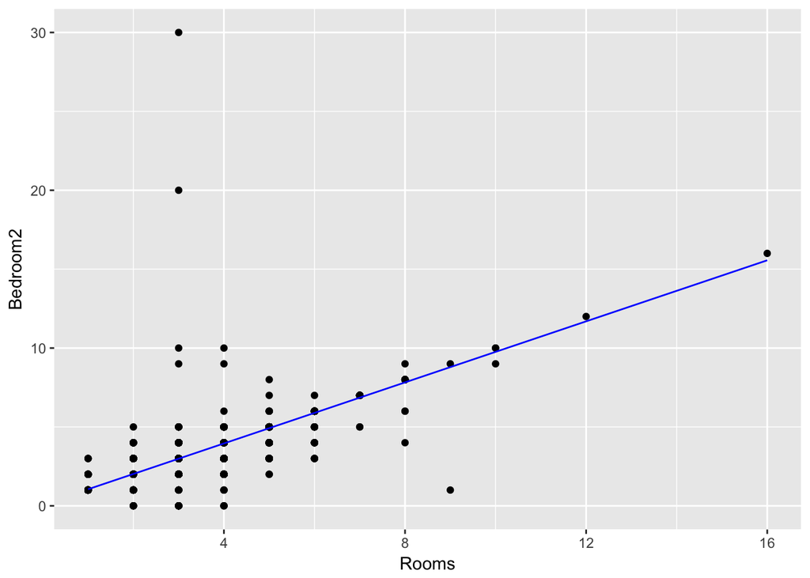

```r
bedroom_model <- augment(houses_fit2, houses1)
ggplot(bedroom_model, aes(x=Rooms, y=Bedroom2)) +
     geom_point() +
     geom_line(aes(y=.fitted), colour="blue")
```

## Initial Regression Analysis: Price and Rooms

```r
no_na_dataset <- na.omit(houses1)
pricehouses_fit <- lm(Price~Rooms, data=no_na_dataset)
tidy(pricehouses_fit)
```

```
##          term estimate std.error statistic      p.value
## 1 (Intercept) 149082.9 13746.385  10.84524 2.486259e-27
## 2       Rooms 307354.2  4290.853  71.63009 0.000000e+00
```

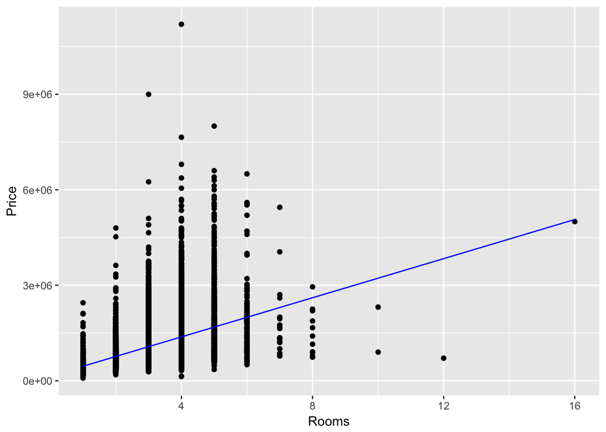

```r
priceshouses_model <- augment(pricehouses_fit, no_na_dataset)
ggplot(priceshouses_model, aes(x=Rooms, y=Price)) +
     geom_point() +
     geom_line(aes(y=.fitted), colour="blue")
```

In order to accurately represent this data, we have taken out all NA values - this is represented by no_na_dataset which omits all observations with NA values (for comparrison sake, this dataset contains 20,800 observations out of the original 34,857).

## Initial Regression Analysis: Price and Bedrooms

Again, it must be noted that no_na_dataset is utilised here, not houses1. We observe a positive linear trend.

```r
pricebedrooms_fit <- lm(Price~Bedroom2, data=no_na_dataset)
tidy(pricebedrooms_fit)
```

```
##          term estimate std.error statistic      p.value
## 1 (Intercept) 194264.0 13654.745  14.22685 1.023244e-45
## 2    Bedroom2 294045.2  4277.342  68.74484 0.000000e+00
```

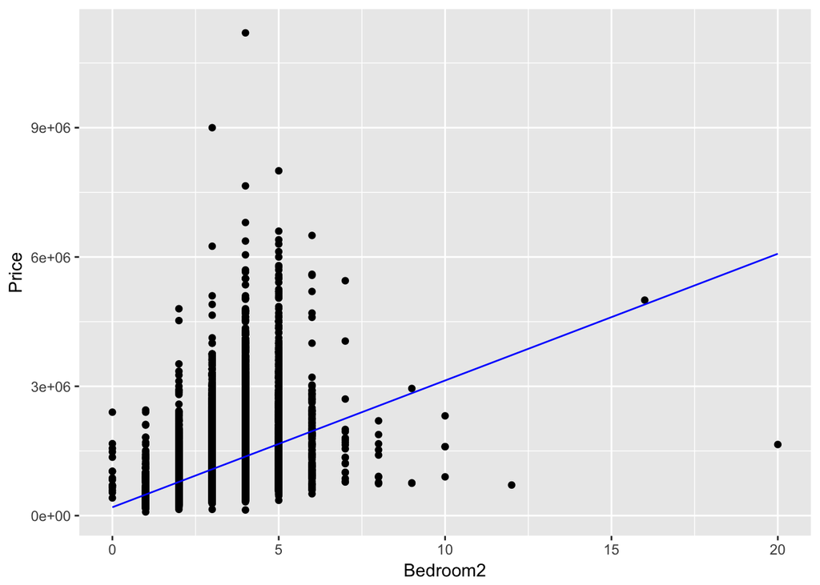

```r
pricebedrooms_model <- augment(pricebedrooms_fit, no_na_dataset)
ggplot(pricebedrooms_model, aes(x=Bedroom2, y=Price)) +
     geom_point() +
     geom_line(aes(y=.fitted), colour="blue")
```